# Final Project EDA

Gregory Glatzer

4/6/2021

# Setup

```r
library(mosaic)
library(tidyverse)
library(ggplot2)
library(ggallin)

rm(list = ls())
```

## Project Overview

For this project, I aim to gather an understanding of the distribution of wages for musicians and singers across the United States. Being a musician myself, this data is interesting to me, to see what people are really being paid for playing music in a professional setting. In addition to looking at the pay of musicians, I also hope to look at wages in a geographic scope, seeing how it various across coasts, cities, and geographic regions.

## Research Question

How does the distribution of professional musicians and their wage vary across geographic regions of the United States?

## Load data

```r
# https://datausa.io/profile/soc/musicians-and-singers
BLS <- readr::read_csv("bls_gov_metrowise.csv")
# https://www.newmusicorganizingcaucus.org/real-music-wages-database.html
Wages <- readr::read_csv("Music Wage DB.csv")
```

## EDA

### Musicians and Singers dataset from BLS

One immediate issue with this dataset is that the locations are not separate fields, but rather a portion of the “Area Name” column. A first step to work with the data would be to extract the locations, and put the numbers in parenthesis (PUMA Codes) in their own column using regex expressions.

```r
BLS %>% head()
```

| Area Name | Employment(1) | Employment percent relative standard error(3) | Hourly mean wage | Annual mean wage(2) | Wage percent relative standard error(3) | Hourly 10th percentile wage | Hourly 25th percentile wage | Hourly median wage | Hourly 75th percentile wage | Hourly 90th percentile wage | Annual 10th percentile wage(2) | Annual 25th percentile wage(2) | Annual median wage(2) | Annual 75th percentile wage(2) | Annual 90th percentile wage(2) | Employment per 1,000 jobs | Location Quotient |
| --- | --- | --- | --- | --- | --- | --- | --- | --- | --- | --- | --- | --- | --- | --- | --- | --- | --- |
| Akron, OH(0010420) | 30 | 34.2 | - | - | - | - | - | - | - | - | - | - | - | - | - | 0.109 | 0.44 |
| Albany, OR(0010540) | 70 | 29.4 | 16.47 | - | 17.5 | 11.23 | 11.24 | 11.24 | 12.22 | 37.28 | - | - | - | - | - | 1.562 | 6.25 |
| Albany-Schenectady-Troy, NY(0010580) | 60 | 41.7 | - | - | - | - | - | - | - | - | - | - | - | - | - | 0.149 | 0.6 |
| Ann Arbor, MI(0011460) | - | - | 37.08 | - | 17.4 | 13.45 | 15.57 | 39.56 | 48.56 | 62.38 | - | - | - | - | - | - | - |
| Appleton, WI(0011540) | 70 | 10 | 11.38 | - | 7.8 | 7.58 | 7.95 | 8.58 | 9.21 | 22.28 | - | - | - | - | - | 0.584 | 2.34 |
| Arizona nonmetropolitan area(0400001) | - | - | 13.4 | - | 5.9 | 12.1 | 12.53 | 13.41 | 14.29 | 14.81 | - | - | - | - | - | - | - |

```r
BLS <- BLS %>%
  rename(areaName = "Area Name") %>%
  extract(areaName, c("PUMA"), "\\((.*)\\)", remove = FALSE) %>% #Get PUMA Code
  extract(areaName, c("areaName"), "(.*)\\(")

BLS %>% head()
```

| areaName | PUMA | Employment(1) | Employment percent relative standard error(3) | Hourly mean wage | Annual mean wage(2) | Wage percent relative standard error(3) | Hourly 10th percentile wage | Hourly 25th percentile wage | Hourly median wage | Hourly 75th percentile wage | Hourly 90th percentile wage | Annual 10th percentile wage(2) | Annual 25th percentile wage(2) | Annual median wage(2) | Annual 75th percentile wage(2) | Annual 90th percentile wage(2) | Employment per 1,000 jobs | Location Quotient |
| --- | --- | --- | --- | --- | --- | --- | --- | --- | --- | --- | --- | --- | --- | --- | --- | --- | --- | --- |
| Akron, OH | 0010420 | 30 | 34.2 | - | - | - | - | - | - | - | - | - | - | - | - | - | 0.109 | 0.44 |
| Albany, OR | 0010540 | 70 | 29.4 | 16.47 | - | 17.5 | 11.23 | 11.24 | 11.24 | 12.22 | 37.28 | - | - | - | - | - | 1.562 | 6.25 |
| Albany-Schenectady-Troy, NY | 0010580 | 60 | 41.7 | - | - | - | - | - | - | - | - | - | - | - | - | - | 0.149 | 0.6 |
| Ann Arbor, MI | 0011460 | - | - | 37.08 | - | 17.4 | 13.45 | 15.57 | 39.56 | 48.56 | 62.38 | - | - | - | - | - | - | - |
| Appleton, WI | 0011540 | 70 | 10 | 11.38 | - | 7.8 | 7.58 | 7.95 | 8.58 | 9.21 | 22.28 | - | - | - | - | - | 0.584 | 2.34 |
| Arizona nonmetropolitan area | 0400001 | - | - | 13.4 | - | 5.9 | 12.1 | 12.53 | 13.41 | 14.29 | 14.81 | - | - | - | - | - | - | - |

I will also need to remove the dashes “-” and replace them with NA values

```r
BLS <- BLS %>%
  na_if("-")
```

Let’s also do some type casting

```r
BLS <- BLS %>%
 type_convert()
```

Now Let’s look at the distributions of some columns

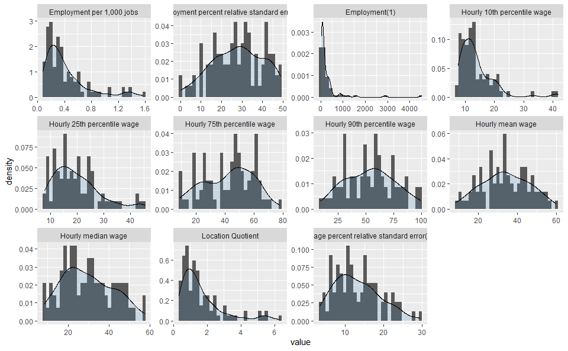

```r
BLS %>%
  keep(is.numeric) %>%
  gather() %>%
  ggplot(aes(x = value)) +
    geom_histogram(aes(y=..density..)) + # we use .. here to use the word "density" which is passed into the aes() mapping from geom_histogram()
    geom_density(alpha=.2, fill="steelblue") +
    facet_wrap(~ key, scales = "free")
```

From https://drsimonj.svbtle.com/quick-plot-of-all-variables, I found an easy way to plot the distribution of all numeric variables at once. It uses `keep(is.numeric)` to filter out non-numeric columns and `gather()` so you don’t have to loop through all the columns with a for loop!

What stands out to me is that in `Employment(1)`, `Hourly 10th percentile wage`, `Employment per 1,000 jobs`, and `Location Quotient`, the data seems to be skewed right. This means that most of the PUMA regions fall around the same wage, but there are a couple that stand out higher than the rest. I wonder if these higher areas are music centers, such as New York, Chicago, LA, and Philadelphia?

I find the Location Quotient especially interesting. The BLS defines location quotient as:

> “Location quotients compare the concentration of an industry within a specific area to the concentration of that industry nationwide”

> — https://www.bls.gov/cew/about-data/location-quotients-explained.htm

Let’s look into this a little further. A common practice for classifying outliers is any value more than 1.5 x the IQR can be considered an outlier. If we can identify outliers, these PUMA codes may be of interest.

```r
BLS$`Location Quotient` %>% summary()
```

```
   Min. 1st Qu.  Median    Mean 3rd Qu.    Max.    NA's
  0.310   0.810   1.280   1.669   2.040   6.250      23
```

```r
# calculate IQR
IQR <- 2.040 - 0.810
upper_cutoff <- 2.040 + (IQR * 1.5)
LocQuoOutliers <- BLS %>%
  filter(`Location Quotient` > upper_cutoff)

LocQuoOutliers
```

| areaName | PUMA | Employment(1) | Employment percent relative standard error(3) | Hourly mean wage | Annual mean wage(2) | Wage percent relative standard error(3) | Hourly 10th percentile wage | Hourly 25th percentile wage | Hourly median wage | Hourly 75th percentile wage | Hourly 90th percentile wage | Annual 10th percentile wage(2) | Annual 25th percentile wage(2) | Annual median wage(2) | Annual 75th percentile wage(2) | Annual 90th percentile wage(2) | Employment per 1,000 jobs | Location Quotient |
| --- | --- | --- | --- | --- | --- | --- | --- | --- | --- | --- | --- | --- | --- | --- | --- | --- | --- | --- |
| Albany, OR | 0010540 | 70 | 29.4 | 16.47 | NA | 17.5 | 11.23 | 11.24 | 11.24 | 12.22 | 37.28 | NA | NA | NA | NA | NA | 1.562 | 6.25 |
| Eugene, OR | 0021660 | 210 | 23.2 | 28.43 | NA | 23.3 | 11.41 | 11.91 | 14.77 | 44.51 | 53.67 | NA | NA | NA | NA | NA | 1.406 | 5.62 |
| Great Falls, MT | 0024500 | 40 | 18.6 | NA | NA | NA | NA | NA | NA | NA | NA | NA | NA | NA | NA | NA | 1.304 | 5.22 |
| Hawaii / Kauai nonmetropolitan area | 1500001 | 120 | 30.0 | 44.83 | NA | 9.4 | 19.50 | 24.96 | 49.50 | 58.00 | 62.98 | NA | NA | NA | NA | NA | 1.341 | 5.36 |
| Kahului-Wailuku-Lahaina, HI | 0027980 | 90 | 48.6 | 33.19 | NA | 10.8 | 19.95 | 25.65 | 32.15 | 41.36 | 48.41 | NA | NA | NA | NA | NA | 1.393 | 5.57 |
| Missoula, MT | 0033540 | 60 | 32.5 | 10.03 | NA | 7.1 | 8.76 | 8.93 | 9.20 | 9.81 | 11.88 | NA | NA | NA | NA | NA | 1.066 | 4.26 |
| Nashville-Davidson--Murfreesboro--Franklin, TN | 0034980 | 1230 | 20.6 | 36.24 | NA | 20.9 | 8.19 | 9.36 | 28.81 | 44.09 | 75.99 | NA | NA | NA | NA | NA | 1.272 | 5.09 |
| Urban Honolulu, HI | 0046520 | 440 | 16.1 | 33.69 | NA | 10.4 | 13.17 | 22.24 | 30.53 | 47.06 | 51.62 | NA | NA | NA | NA | NA | 1.050 | 4.20 |

Regarding my research question, these PUMA areas may be troublesome, as if I were to make a map where location quotient was mapped to the radius of the points on the map, these locations may be especially large. My options could be to drop these rows, or more likely put this variable on a log scale.

It is interesting when you compare this to hourly mean wage, which has a fairly normal, bell-shaped distribution. Although there are some areas with high concentration of musicians, there are not extreme outliers of wage to match these concentrations.

In order to investigate this further, I want to make a jitter plot of the hourly mean wage, and highlight these outliers to see where they fall.

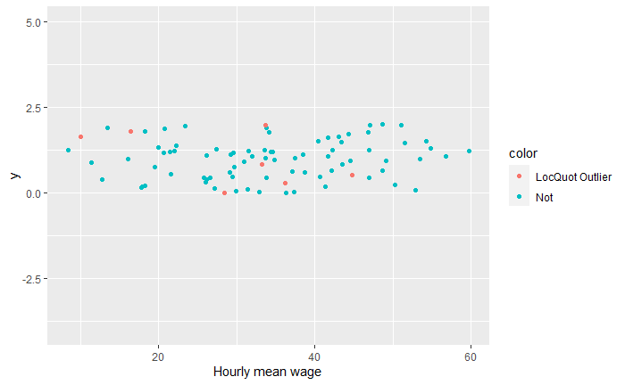

```r
jitter <- position_jitter(width = 0, height = 1)

BLS$color <- ifelse(BLS$areaName %in% LocQuoOutliers$areaName, "LocQuot Outlier", "Not")

BLS %>%
  ggplot() +
  geom_point(
    position = jitter,
    aes(x = `Hourly mean wage`, y = 1, color = color)) +
  ylim(-4, 5)
```

Interestingly, these areas are not in any particular range of wages, so it doesn’t seem that Location Quotient has a strong correlation between Hourly mean wage.

In contrast, If we look at the `Employment per 1,000 jobs`…

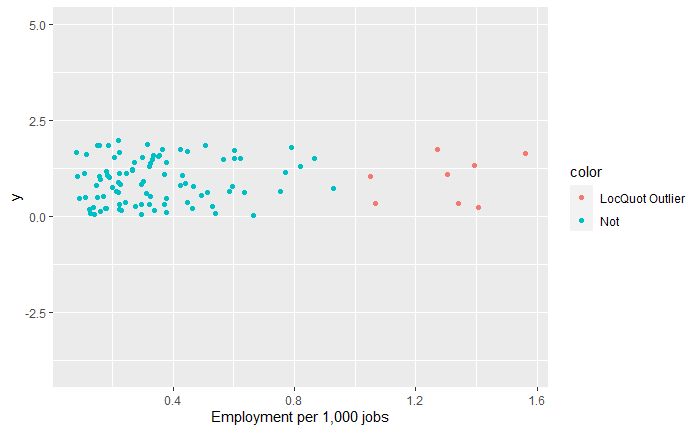

```r
jitter <- position_jitter(width = 0, height = 1)

BLS$color <- ifelse(BLS$areaName %in% LocQuoOutliers$areaName, "LocQuot Outlier", "Not")

BLS %>%
  ggplot() +
  geom_point(
    position = jitter,
    aes(x = `Employment per 1,000 jobs`, y = 1, color = color)) +
  ylim(-4, 5)
```

…we can see that these Location Quotient outliers are also the outliers here. So if we were to want to perform some sort of machine learning with this dataset, a possible option of dimensionality reduction / feature selection may be to only choose one of these variables, as they are related.

## EDA with Music Wages DB

This dataset is from an online survey for musicians to enter information about gigs they have done recently. It can be found [here](https://www.newmusicorganizingcaucus.org/real-music-wages-database.html).

```r
Wages %>% head()
```

| timestamp | whopaid | howmuch | howlong | where | tags | tour? | union? |
| --- | --- | --- | --- | --- | --- | --- | --- |
| 11/24/2020 16:42 | Alarm Will Sound | 1017.5 | 7.5 | St. Louis, MO, USA | the grandel, small ensemble, new music | NA | NA |
| 11/24/2020 16:42 | Alarm Will Sound | 850 | 8 | Hanover, NH, USA | dartmouth university, shift festival, small ensemble, new music | NA | NA |
| 1/9/2021 11:42 | Alarm Will Sound | 1900 | 43 | St. Louis, MO, USA | small ensemble, new music | NA | NA |
| 1/26/2021 18:10 | American Composers Association | 175 | 8 | New York, NY, USA | solo,home recording,new music | NA | NA |
| 1/26/2021 18:10 | American Composers Association | 150 | 1 | New York, NY, USA | home recording,new music,solo | NA | NA |
| 1/18/2021 19:55 | American Composers Orchestra | 150 | 3.5 | New York, NY, USA | orchestra, new music, composer reading | NA | NA |

Type casting before I even start. Also remove the NA columns.

```r
Wages <- Wages %>%
  select(whopaid, howmuch, howlong, where) %>%
  mutate(
    whopaid = as.factor(whopaid),
    howmuch = as.numeric(howmuch),
    howlong = as.numeric(howlong),
    )
```

```
NAs introduced by coercionNAs introduced by coercion
```

```r
Wages
```

| whopaid | howmuch | howlong | where |
| --- | --- | --- | --- |
| Alarm Will Sound | 1017.50 | 7.50 | St. Louis, MO, USA |
| Alarm Will Sound | 850.00 | 8.00 | Hanover, NH, USA |
| Alarm Will Sound | 1900.00 | 43.00 | St. Louis, MO, USA |
| American Composers Association | 175.00 | 8.00 | New York, NY, USA |
| American Composers Association | 150.00 | 1.00 | New York, NY, USA |
| American Composers Orchestra | 150.00 | 3.50 | New York, NY, USA |
| American Composers Orchestra | 15000.00 | 486.00 | New York, NY, USA |
| Art of Elan | 500.00 | 5.00 | San Diego, CA, USA |
| Arts for Art | 150.00 | NA | New York, NY, USA |
| Association for the Promotion of New Music | 500.00 | 15.00 | New York, NY, USA |

[output cut: 111 more lines]

Let’s look at how much people are being paid for gigs.

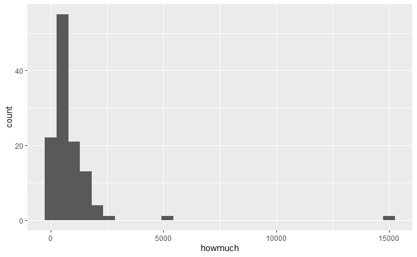

```r
Wages %>%
  ggplot() +
  geom_histogram(aes(x = howmuch))
```

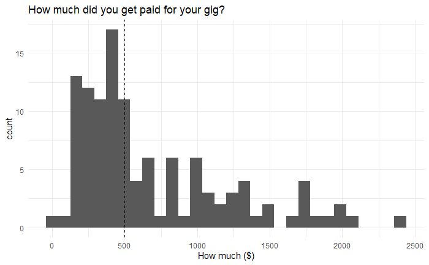

```r
Wages %>%
  filter(howmuch < 5000) %>%
  ggplot() +
  geom_histogram(aes(x = howmuch)) +
  geom_vline(aes(xintercept = median(howmuch)), linetype = "dashed") +
  labs(title = "How much did you get paid for your gig?") +
  xlab("How much ($)") +
  theme_minimal()
```

Much better. The data is still skewed right, but the majority of data is ~$750 or less. The median is 500, as shown by the dashed line.

Now let’s look at how long the gigs were.

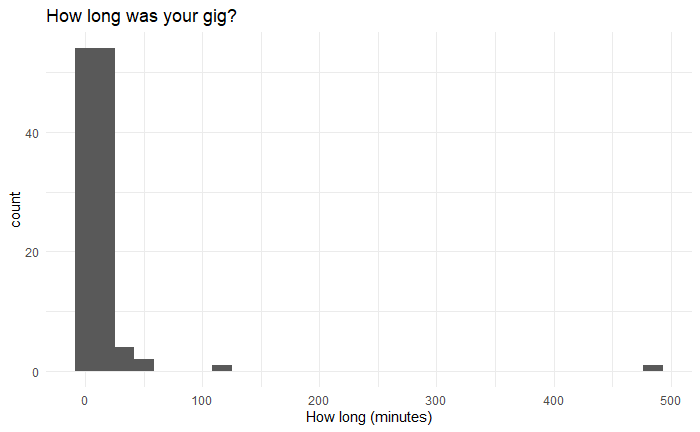

```r
Wages %>%
  ggplot() +
  geom_histogram(aes(x = howlong)) +
  geom_vline(aes(xintercept = median(howlong)), linetype = "dashed") +
  labs(title = "How long was your gig?") +
  xlab("How long (minutes)") +
  theme_minimal()
```

Once again there is an outrageous outlier. My guess is this is a typo by someone filling out the form.

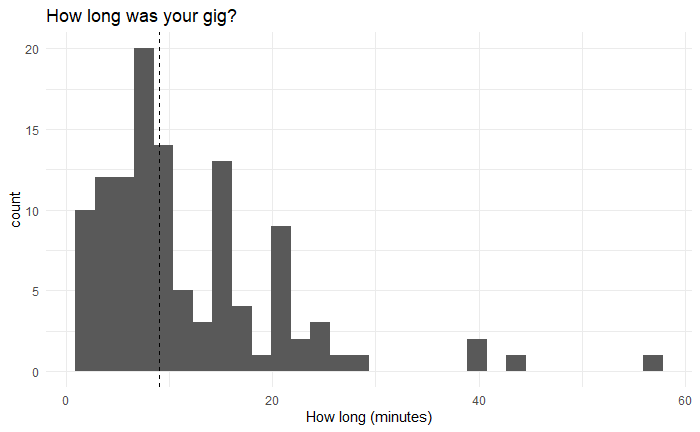

```r
Wages %>%
  filter(howlong < 100) %>%
  ggplot() +
  geom_histogram(aes(x = howlong)) +
  geom_vline(aes(xintercept = median(howlong)), linetype = "dashed") +
  labs(title = "How long was your gig?") +
  xlab("How long (minutes)") +
  theme_minimal()
```

Once again skewed right. This may mean that how long has a positive correlation with how much. Let’s investigate that.

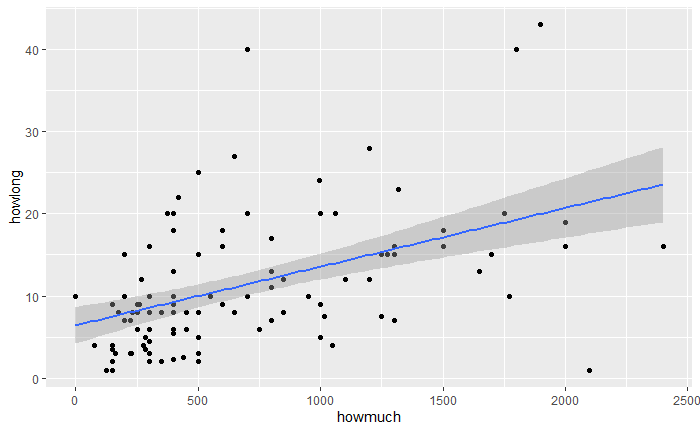

```r
Wages %>%
  filter(howmuch < 5000) %>%
  ggplot(aes(x = howmuch, y = howlong)) +
  geom_point() +
  geom_smooth(stat = "lm")
```

```r
NA
```

If we fit a straight line to the data, there is a positive slope, however the points don’t look very close to the regression line. Let’s see what R^2 is.

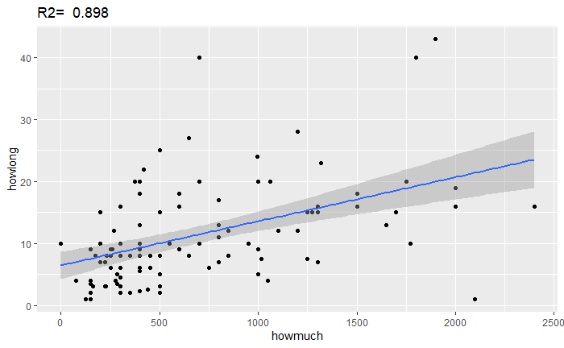

```r
m <- lm(howlong ~ howmuch, data = Wages)

Wages %>%
  filter(howmuch < 5000) %>%
  ggplot(aes(x = howmuch, y = howlong)) +
  geom_point() +
  stat_smooth(method = "lm") +
  labs(title = paste("R2= ", signif(summary(m)$r.squared, digits = 3)))
```

## Bringing the datasets together

The last thing I want to do in this EDA is bring the datasets together and plot them on a map. I will do this with the state abbreviations. There is some limitations to what I can do, since there are not *too* many states represented in the wages dataset.

```r
Wages %>%
  distinct(where)
```

| where |
| --- |
| St. Louis, MO, USA |
| Hanover, NH, USA |
| New York, NY, USA |
| San Diego, CA, USA |
| Austin, TX, USA |
| Boston, MA, USA |
| Hauppauge, NY, USA |
| Portland, OR, USA |
| New York, NY, USA (virtual) |
| Chicago, IL |

[output cut: 31 more lines]

The abbreviations, or lackthereof, are not consistent. There are few enough unique values, that I can do fix it manually with some mutates.

```r
Wages <- Wages %>%
  mutate(where = replace(where, where=="asheville, nc", "Asheville, NC")) %>%
  mutate(where = replace(where, where=="Los Angeles", "Los Angeles, CA")) %>%
  mutate(where = replace(where, grepl("Florida", where, ignore.case = TRUE), ", FL")) %>%
  mutate(where = replace(where, grepl("New York metro", where, ignore.case = TRUE), ", NY"))

Wages %>% distinct(where)
```

| where |
| --- |
| St. Louis, MO, USA |
| Hanover, NH, USA |
| New York, NY, USA |
| San Diego, CA, USA |
| Austin, TX, USA |
| Boston, MA, USA |
| Hauppauge, NY, USA |
| Portland, OR, USA |
| New York, NY, USA (virtual) |
| Chicago, IL |

[output cut: 30 more lines]

Let’s extract the state abbreviations using regex.

```r
Wages <- Wages %>%
  mutate(state = str_extract(where, "(?<=, )([A-Z]{2})"))

BLS <- BLS %>%
  mutate(state = str_extract(areaName, "(?<=, )([A-Z]{2})"))
```

Now I want to compare the average wage in each state in the Wages dataset with the average in the corresponding state in the BLS dataset, to see how representative the Wages survey is of the BLS statistics.

```r
Comparison <- BLS %>%
  drop_na(`Hourly mean wage`) %>%
  group_by(state) %>%
  summarize(avgWage = mean(`Hourly mean wage`)) %>%
  right_join(Wages) %>%
  mutate(surveyWage = howmuch / howlong) %>%
  drop_na(surveyWage) %>%
  drop_na(avgWage) %>%
  group_by(state) %>%
  summarize(avgSurveyWage = mean(surveyWage), avgStateWage = mean(avgWage)) %>%
  select(state, avgSurveyWage, avgStateWage) %>%
  mutate(diff = avgSurveyWage - avgStateWage)
Comparison
```

| state | avgSurveyWage | avgStateWage | diff |
| --- | --- | --- | --- |
| CA | 45.00000 | 39.50000 | 5.50000 |
| IL | 80.00000 | 48.70000 | 31.30000 |
| MA | 74.50658 | 43.02500 | 31.48158 |
| MD | 41.45833 | 29.18000 | 12.27833 |
| MI | 113.50000 | 35.95000 | 77.55000 |
| MN | 87.50000 | 50.24000 | 37.26000 |
| MO | 78.81734 | 37.42500 | 41.39234 |
| NC | 150.00000 | 35.32667 | 114.67333 |
| NJ | 52.25000 | 59.78000 | -7.53000 |
| NY | 73.37422 | 31.14167 | 42.23255 |

[output cut: 6 more lines]

```r
# https://stackoverflow.com/questions/5411979/state-name-to-abbreviation
ConversionTable <- tibble(state = state.name) %>%
   bind_cols(tibble(abb = state.abb)) %>% rename(stateFull = state)

# https://rstudio-pubs-static.s3.amazonaws.com/446253_b0059ba404ec418db41bbd5517bf818d.html
all_states <- map_data("state")

Comparison$diff <- if_else(Comparison$diff > 0, log(Comparison$diff), -log(-Comparison$diff)) # put it on a log scale, both positive and negative
```

```
NaNs producedNaNs produced
```

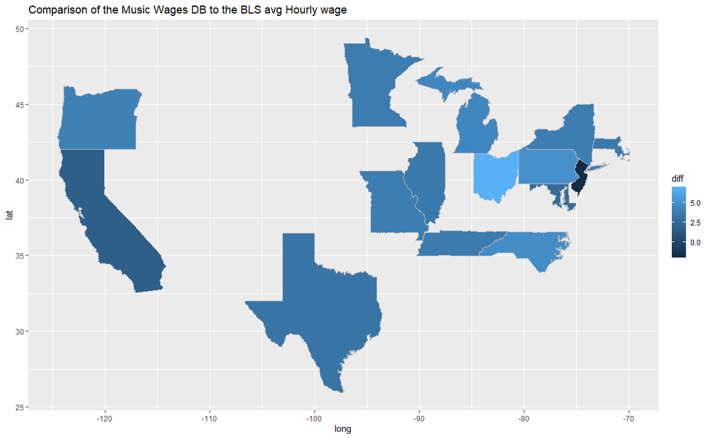

```r
Comparison %>%
  left_join(ConversionTable, by = c("state" = "abb")) %>%
  mutate(stateFull = str_to_lower(stateFull)) %>%
  left_join(all_states, by = c("stateFull" = "region")) %>%
  ggplot(aes(long, lat, group = group, fill = diff)) +
  geom_polygon(color = "grey") +
  labs(title = "Comparison of the Music Wages DB to the BLS avg Hourly wage")
```

This map does not show every state because, in reality, these datasets are not that big. Even though, we can see that most states are positive, which means that the wages coming out of the Music Wage DB datasets wre higher on average than what the BLS dataset said musician wages were for that state. It is also worth noting that the colors are on a log scale, since Ohio was sticking out too much and making the color spectrum useless.